# Prag Bat Summary

# Objective

Assess reliability of and relations between different pragmatic inference tasks which we have developed over the years.

# Study 1 and 2

## Sample size

Our goal was to test at least 20 children per age group and round twice. Children were tested in a kindergarten in Leipzig.

| study | subage | n | complete_retest_data |
| --- | --- | --- | --- |
| S1 | 3 | 23 | 21 |
| S1 | 4 | 25 | 21 |
| S2 | 3 | 27 | 21 |
| S2 | 4 | 27 | 19 |

## Results by Task

All tasks had 5 trials, except for card sorting, which had 6. All subjects got the tasks in the same order and the same version of each task.

Study 1 included the following tasks:

- Informativeness (same setup and stimuli as in MCC)
- Preference (as in MCC)
- Novelty (as in SPIN)
- Mutual exclusivity (as in SPIN, with fewer items)
- Card sorting (DCCS sensu Zelazo, 2006)

Study 2 included the following tasks:

- Simple informativeness (same setup and stimuli as in Frank & Goodman, 2014)
- Ad-hoc implicature (same stimuli as Yoon & Frank, 2019)
- Discourse continuity (as in DISCON)
- Mutual exclusivity (as in SPIN, with fewer items, same as R1)
- Card sorting (DCCS sensu Zelazo, 2006, same as R1)

For mutual exclusivity and card sorting we have a direct replication. The plot below shows all data, including data from children who were tested only once.

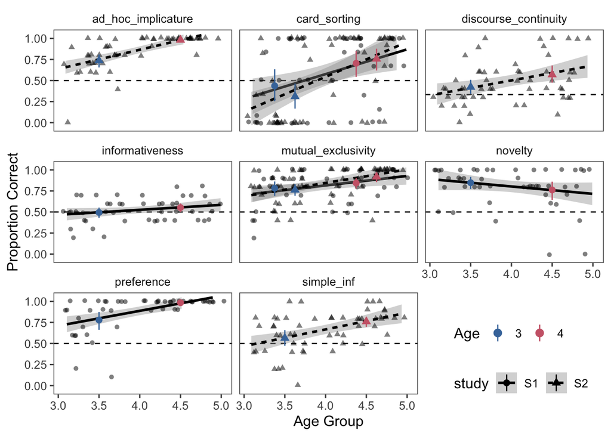

## Reliability

Based on simple Pearson correlations on the data aggregated by subject, task and test day.

| study | task | reli | lci | uci | p | n |
| --- | --- | --- | --- | --- | --- | --- |
| S1 | card_sorting | 0.63 | 0.41 | 0.79 | 0.00 | 42 |
| S1 | informativeness | 0.21 | -0.10 | 0.48 | 0.18 | 42 |
| S1 | mutual_exclusivity | 0.72 | 0.54 | 0.84 | 0.00 | 42 |
| S1 | novelty | 0.79 | 0.64 | 0.88 | 0.00 | 42 |
| S1 | preference | 0.74 | 0.56 | 0.85 | 0.00 | 42 |
| S2 | ad_hoc_implicature | 0.68 | 0.46 | 0.82 | 0.00 | 40 |
| S2 | card_sorting | 0.77 | 0.61 | 0.87 | 0.00 | 40 |
| S2 | discourse_continuity | 0.60 | 0.36 | 0.77 | 0.00 | 40 |
| S2 | mutual_exclusivity | 0.71 | 0.52 | 0.84 | 0.00 | 40 |
| S2 | simple_inf | 0.69 | 0.49 | 0.83 | 0.00 | 40 |

Explore consolidating across studies.

| task | reli | lci | uci | p | n |
| --- | --- | --- | --- | --- | --- |
| novelty | 0.79 | 0.64 | 0.88 | 0.00 | 42 |
| preference | 0.74 | 0.56 | 0.85 | 0.00 | 42 |
| mutual_exclusivity | 0.72 | 0.59 | 0.81 | 0.00 | 82 |
| card_sorting | 0.70 | 0.57 | 0.80 | 0.00 | 82 |
| simple_inf | 0.69 | 0.49 | 0.83 | 0.00 | 40 |
| ad_hoc_implicature | 0.68 | 0.46 | 0.82 | 0.00 | 40 |
| discourse_continuity | 0.60 | 0.36 | 0.77 | 0.00 | 40 |
| informativeness | 0.21 | -0.10 | 0.48 | 0.18 | 42 |

## Correlations between tasks

Based on simple Pearson correlations on the data aggregated by subject and task.

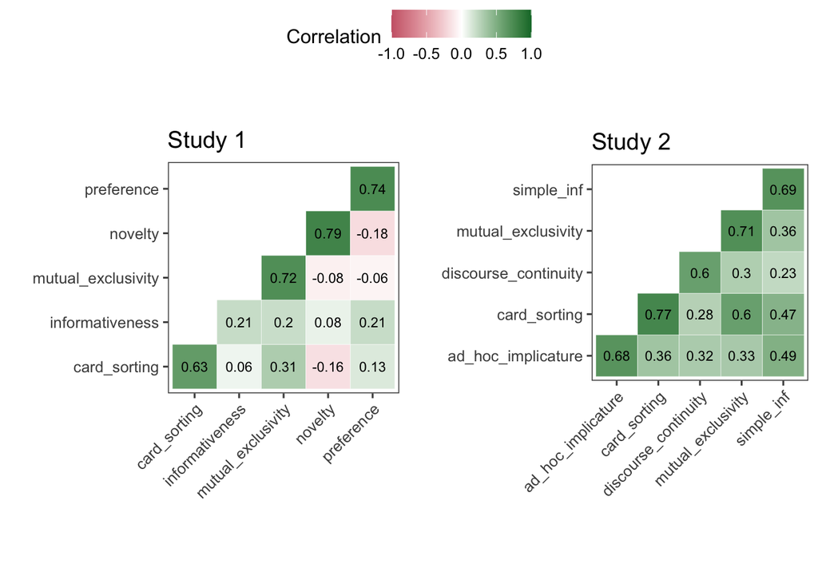

# Study 3

The goal of Study 3 was to select some tasks from Study 1 and 2 and collect data from a larger sample to look more closely at the relations between tasks. We aimed for 120 children (60 3yo, 60 4yo).

Study 3 included the following tasks:

- Simple informativeness (same setup and stimuli as in Frank & Goodman, 2014, same as S2)
- Ad-hoc implicature (same stimuli as Yoon & Frank, 2019, same as S2)
- Mutual exclusivity (as in SPIN, with fewer items, same as S1 and S2)
- Card sorting (DCCS sensu Zelazo, 2006, same as S1 and S2)
- Match to sample (setup and stimuli from Christie & Gentner, 2013)

In contrast to Study 1 and 2, we tested participants only once, with 5 or 6 trials per task.

## Sample size

| subage | n |
| --- | --- |
| 3 | 61 |
| 4 | 65 |

## Results by task

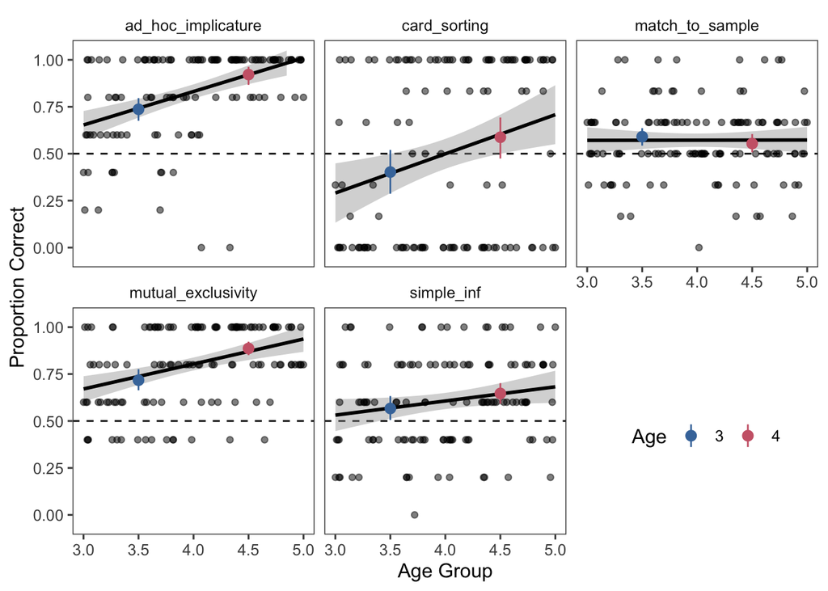

Results replicate the previous studies. The newly added match-to-sample task did not work too well in that we have no solid group-level performance above chance for the two age groups and no age effect. Reliability for the task is also unknown as it was not part of the previous studies.

## Correlations between tasks

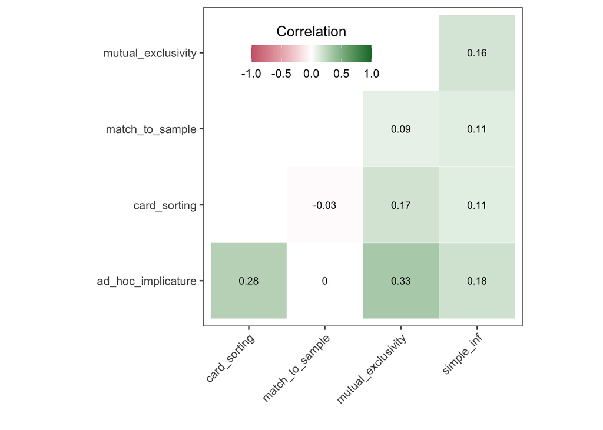

Correlations between tasks are lower compared to Study 1 and 2. This was expected since we only have half the number of trials in this study (Study 1 and 2 both had two test days, here we only had 1). Nevertheless, the overall pattern seems similar to study 2.

## Factor analysis

Given the low number of tasks, exploratory factor analysis does not make much sense because a one factor model will always be favored. Instead, I fit the CFA model that I thought best represents our theoretical view of the data. That is, a pragmatics factor with the three tasks as indicators, which is then correlated with the match-to-sample and the card sorting task:

`prag =~ ad_hoc_implicature + mutual_exclusivity + simple_inf`

`card =~ card_sorting`

`match =~ match_to_sample`

Figure below shows the result from the frequentist model. A Bayesian version produces essentially the same results (but takes forever to run and is more difficult to visualize). All fit indices for the frequentist and the Bayesian model show a good fit (see below for frequentist model - hints for interpretation: https://easystats.github.io/effectsize/reference/interpret_gfi.html).

| index | value |
| --- | --- |
| chisq | 3.20837322 |
| df | 4.00000000 |
| pvalue | 0.52357959 |
| cfi | 1.00000000 |
| rmsea | 0.00000000 |
| rmsea.ci.lower | 0.00000000 |
| rmsea.ci.upper | 0.12290897 |
| srmr | 0.03541019 |

Graph below shows standardized model coefficients from frequentist model. As you can see the pragmatics factor is related to the card sorting task but not to the match-to-sample task.

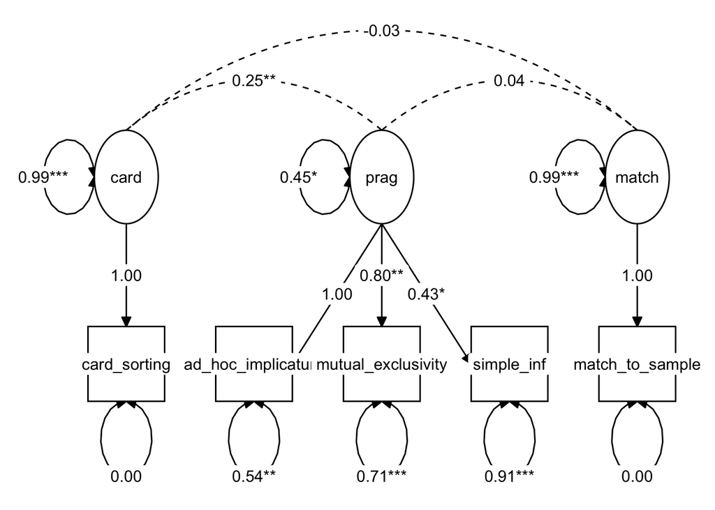

In a Bayesian model comparison via WAIC the model above does better compared to two (not very strong) alternative models: a `single factor model` and a `one factor per task model`.

## RSA model

One of the reasons we picked the three pragmatics tasks we did was that we can all model them via RSA. That is, we can estimate a value for $\alpha$ for each participant based on the data from those three tasks. To account for different difficulties, there is an additional scale parameter that adjusts $\alpha$ for each task. In the end, we can treat the participant specific $\alpha$ estimate like a factor score and correlate it with the other two tasks. The results are quite similar to the CFA model above.

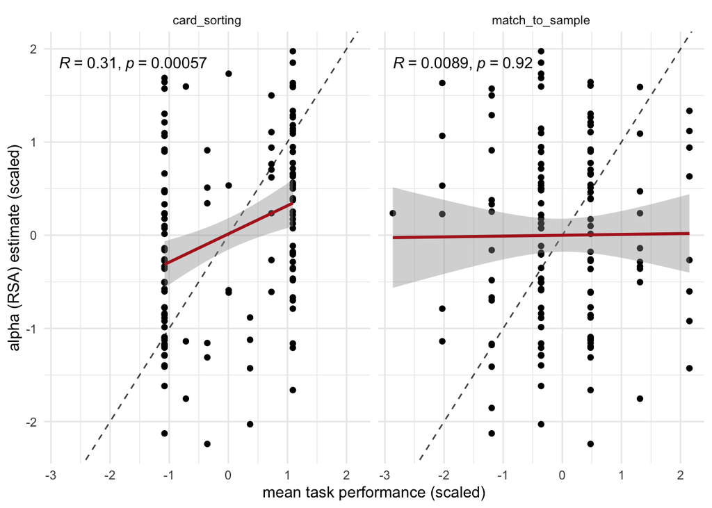

## Things to discuss

- should we take out the match-to-sample task (unknown reliability, unsure if it “worked”) and instead include the data from study 2 in the CFA/RSA model?
- RSA or CFA or both?